# US Presidential Keyness Plot

Zahra Rahmani

# Analysis of US Presidential Candidates’ Policies

In this project, I have investigated policies of US presidential candidates in the 2024 election. I have created word clouds from Harris and Trump’s policy documents that reveal what issues they are focusing on and their plans after being elected. I have used policy documents of Harris and Trump extracted from their websites to create word clouds for each candidate and a keyness plot.

Please reach out if you found any mistakes or have trouble running this script!

#### Preliminaries

Let’s first load the required packages!

```r
library(quanteda)
```

```r
library(quanteda.textmodels)
library(quanteda.textplots)
library(quanteda.textstats)
library(ggplot2)
library(pdftools)
library(tidyverse)
library(lattice)
library(stringr)
```

### Kamala Harris

#### Preprocessing

First, I will import the documents related to Harris’s policies which consists of a document related to her policies towards the Black community, another document related to the Latino community and the main “A New Way Forward” document which is 82 pages.

Loading data: These are documents related to her policies towards Black and Latino people.

```r
agenda_black <- read.table(file = "Agenda_Black_Men.txt", header = FALSE, sep = "\t")
agenda_latino <- read.table(file = "Agenda_Latino_Men.txt", header = FALSE, sep = "\t")
```

Renaming columns

```r
agenda_black <- agenda_black %>%
  rename(sentence = V1)
agenda_latino <- agenda_latino %>%
  rename(sentence = V1)
```

This is Harris’s policy book in pdf.

```r
harris_policy_book <- pdf_text("Harris_Policy_Book.pdf") %>%
  read_lines() %>%
  data.frame()
```

Renaming columns

```r
harris_policy_book <- harris_policy_book %>%
  rename(sentence = ".")
```

I will combine the 3 datasets.

```r
harris <- rbind(agenda_latino, agenda_black, harris_policy_book)
```

Let’s clean the data up! I will remove empty cells.

```r
# Let's get rid of empty cells!
harris <- harris %>%
  filter(str_trim(sentence) != "")

# Let's remove all numbers!
harris <- harris %>%
  mutate(sentence = str_remove_all(sentence, "[0-9]"))

# I won't remove symbols or punctuation mark, because later in the tokenization process, I will remove them.

# After removing numbers, there are some empty rows that need to be removed
harris <- harris %>%
  filter(str_trim(sentence) != "")

# And lastly, drop rows that contain single letters. I will get rid of them, too.
harris <- harris %>%
  filter(!str_detect(str_trim(sentence), "^[A-Za-z]$"))
```

I will create a column to label each row with the name of the candidate.

```r
harris <- harris %>%
  mutate(candidate = "harris")
```

Creating a corpus from a dataframe

```r
corp_harris <- corpus(harris, text_field = "sentence")
```

```r
head(summary(corp_harris), 20)
```

```
##      Text Types Tokens Sentences candidate
## 1   text1    23     26         1    harris
## 2   text2    40     48         2    harris
## 3   text3    29     37         1    harris
## 4   text4    29     33         2    harris
## 5   text5    42     54         1    harris
## 6   text6    52     68         1    harris
## 7   text7    15     16         1    harris
## 8   text8    97    151         6    harris
## 9   text9    91    143         5    harris
## 10 text10    78    121         5    harris
## 11 text11    14     16         1    harris
## 12 text12    51     62         2    harris
## 13 text13    26     32         1    harris
## 14 text14    53     70         4    harris
## 15 text15    28     30         1    harris
## 16 text16    23     24         1    harris
## 17 text17    59     93         3    harris
## 18 text18    17     19         1    harris
## 19 text19    37     49         2    harris
## 20 text20    58     76         3    harris
```

#### Tokenization

In this step, let’s conduct tokenization and create a document feature matrix.

```r
harris_toks <- tokens(corp_harris, remove_punct = TRUE, remove_symbols = TRUE, remove_url = TRUE) %>%
  tokens_remove(stopwords("en")) %>%   # Removing all stop words
  tokens_tolower()                    # Making everything lowercase

harris_toks
```

```
## Tokens consisting of 2,643 documents and 1 docvar.
## text1 :
##  [1] "support"     "latino"      "men"         "starting"    "businesses"
##  [6] "building"    "wealth"      "taking"      "care"        "families"
## [11] "getting"     "good-paying"
## [ ... and 3 more ]
##
## text2 :
##  [1] "vice"               "president"          "harris"
##  [4] "build"              "opportunity"        "economy"
##  [7] "everyone—including" "latino"             "men—has"
## [10] "opportunity"        "just"               "get"
## [ ... and 13 more ]
##
## text3 :
##  [1] "president"     "fight"         "lower"         "costs"
##  [5] "latino"        "men"           "families"      "support"
##  [9] "attaining"     "american"      "dream"         "homeownership"
## [ ... and 2 more ]
##
## text4 :
##  [1] "today"     "vice"      "president" "harris"    "outlining" "policy"
##  [7] "agenda"    "tap"       "ambition"  "potential" "latino"    "men"
## [ ... and 3 more ]
##
## text5 :
##  [1] "help"          "latino"        "men"           "entrepreneurs"
##  [5] "startup"       "expand"        "small"         "businesses"
##  [9] "interest"      "loans"         "deferred"      "loan"
## [ ... and 13 more ]
##
## text6 :
##  [1] "foster"        "additional"    "opportunities" "economic"
##  [5] "success"       "well-being"    "latino"        "men"
##  [9] "supporting"    "new"           "training"      "opportunities"
## [ ... and 33 more ]
##
## [ reached max_ndoc ... 2,637 more documents ]
```

The phrase “small businesses” has high frequency in the data but they are presented as separate features, I will combine them as one type. I will also change taxes to tax since both have high frequencies. I will also change business to businesses because the words small and business have high frequencies apart from small businesses and if I transform business to businesses and is accompanied by the adjective small, it will be considered as “small businesses”.

```r
harris_toks <- tokens_replace(harris_toks,
                       pattern = c("american","taxes", "business"),
                       replacement = c("americans","tax", "businesses"),
                       valuetype = "fixed")
```

```r
harris_toks <- tokens_compound(harris_toks, phrase(c("small businesses")))
```

I will create a document feature matrix.

```r
harris_dfmat <- harris_toks %>%
  dfm()
```

I will select only those features that have minimum frequency of 20.

```r
harris_dfmat <- dfm_trim(harris_dfmat, min_termfreq = 20)
```

#### Top Features

```r
print(topfeatures(harris_dfmat))
```

```
## president      vice    harris americans       tax     black       men    latino
##       337       281       262       256       208       184       163       160
##     trump       new
##       158       149
```

I will remove tokens that have high frequency but provide no insight about the data such as president.

```r
harris_dfmat <- dfm_remove(harris_dfmat, pattern = c("president", "vice", "harris", "men", "trump", "new", "million"))
```

Let’s look at the top features after removing features that are not helpful.

```r
print(topfeatures(harris_dfmat))
```

```
##  americans        tax      black     latino   families       care businesses
##        256        208        184        160        147        124        118
##      costs       jobs    workers
##        114        101         99
```

It seems that tax and job in other words employment are the issues that Harris cares. Also, high usage of families, workers, care and costs shows that Harris emphaises on working families’ welfare.

#### Word Cloud

Let’s create a wordcloud.

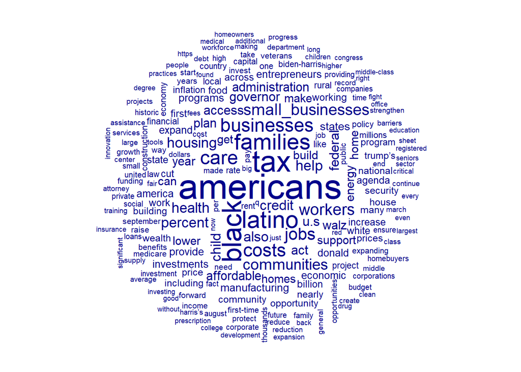

```r
textplot_wordcloud(harris_dfmat, max_words = 250)
```

There are some features that need to be removed like also, percent, take, etc.

```r
harris_dfmat <- dfm_remove(harris_dfmat, pattern = c("making", "september", "back", "including", "nearly", "without", "even", "dollars", "forward", "also", "just", "billion", "march", "per", "q", "harris’s", "trump’s", "one", "like", "percent", "take", "across", "u.s", "can", "every", "way", "august", "first-time", "department", "donald", "https", "biden-harris", "harris-walz", "made", "found", "walz", "year", "billion"))

# The words "way" and "forward" have been removed because the title of the document is "A New Way Forward" so these words have been repeated on every page.
```

Let’s create another word cloud after removing features.

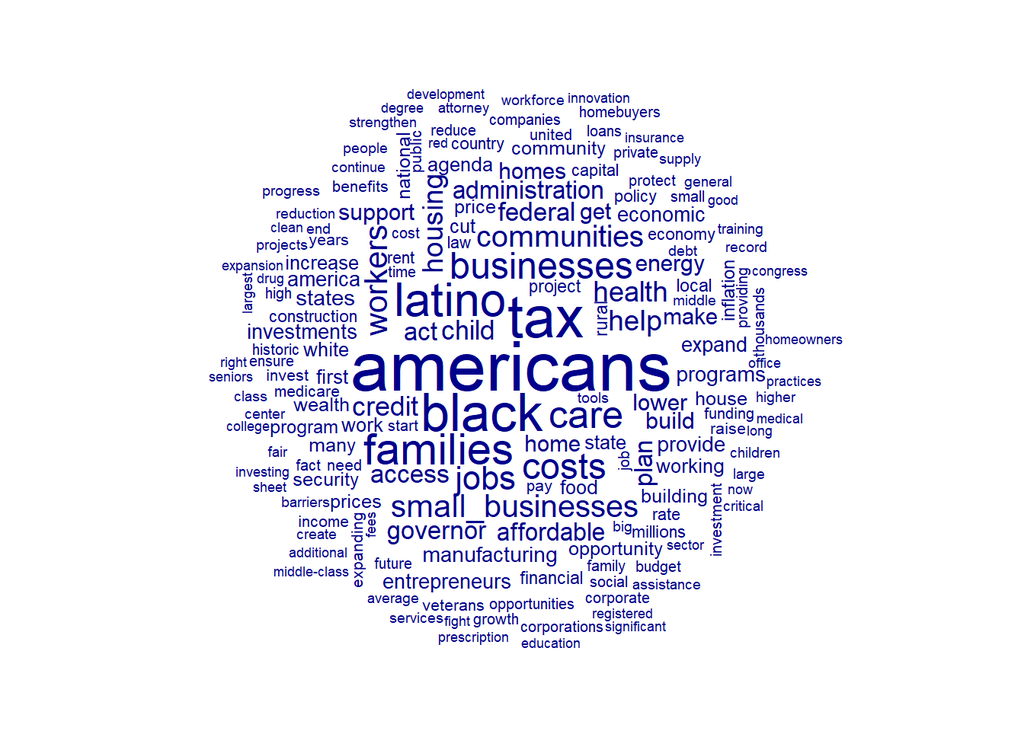

```r
textplot_wordcloud(harris_dfmat, max_words = 250)
```

This is the word cloud for the documents related to Harris’s policies which include the pdf document on her website and other two documents related to Black and Latino people. In this word cloud, tax, black, families, latino, americans, care, costs, business, jobs, workers, communities, housing, affordable, small_businesses, entrepreneurs, manufacturing are the most frequent words.

High frequency of these words shows that Harris will have plans for tax, she will also address the housing issue and other costs for the working families. In addition, she’s going to support businesses including small businesses and entrepreneurs. Black and Latino are also of high frequency in this word cloud, therefore issues related to these communities will be her priority.

Now, I will create a word cloud only for the “A New Way Forward” document and exclude policy documents related to Latino and Black people.

```r
harris_2 <- pdf_text("Harris_Policy_Book.pdf") %>%
  read_lines() %>%
  data.frame()
harris_2 <- harris_2 %>%
  rename(sentence = ".")
```

```r
# Let's get rid of empty cells!
harris_2 <- harris_2 %>%
  filter(str_trim(sentence) != "")

# Let's remove all numbers!
harris_2 <- harris_2 %>%
  mutate(sentence = str_remove_all(sentence, "[0-9]"))

# After removing numbers, there are some empty rows that need to be removed.
harris_2 <- harris_2 %>%
  filter(str_trim(sentence) != "")

# And lastly, drop rows that contain single letters. I will get rid of them.
harris_2 <- harris_2 %>%
  filter(!str_detect(str_trim(sentence), "^[A-Za-z]$"))

harris_2 <- harris_2 %>%
  mutate(candidate = "harris")
```

Creating a corpus from a dataframe

```r
corp_harris_2 <- corpus(harris_2, text_field = "sentence")

harris_toks_2 <- tokens(corp_harris_2, remove_punct = TRUE, remove_symbols = TRUE, remove_url = TRUE) %>%
  tokens_remove(stopwords("en")) %>%   # Removing all stop words
  tokens_tolower()                    # Making everything lowercase
```

```r
harris_toks_2 <- tokens_replace(harris_toks_2,
                       pattern = c("american","taxes", "business"),
                       replacement = c("americans","tax", "businesses"),
                       valuetype = "fixed")
```

```r
harris_toks_2 <- tokens_compound(harris_toks_2, phrase(c("small businesses")))
```

```r
harris_dfmat_2 <- harris_toks_2 %>%
  dfm()
```

I will select only those features that have minimum frequency of 20.

```r
harris_dfmat_2 <- dfm_trim(harris_dfmat_2, min_termfreq = 20)
```

#### Top features

```r
print(topfeatures(harris_dfmat_2))
```

```
## president americans      vice    harris       tax       new      care     trump
##       214       196       186       173       171       118        83        81
##   percent     costs
##        81        79
```

```r
harris_dfmat_2 <- dfm_remove(harris_dfmat_2, pattern = c("president", "vice", "harris", "new", "trump", "percent", "u.s", "million", "administration", "walz"))
```

```r
print(topfeatures(harris_dfmat_2))
```

```
##        americans              tax             care            costs
##              196              171               83               79
##          workers         families       businesses         governor
##               77               74               71               70
## small_businesses             jobs
##               66               65
```

#### Word Cloud: A New Way Forward

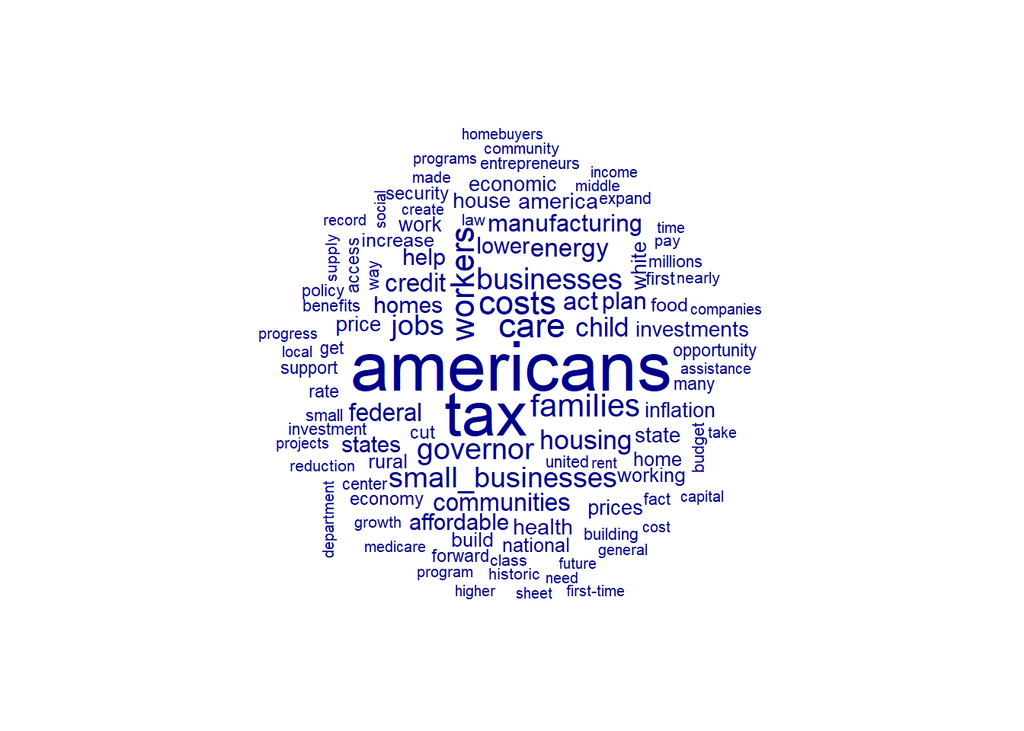

```r
harris_dfmat_2 <- dfm_remove(harris_dfmat_2, pattern = c("years", "factmade", "including", "september", "donald", "per", "harris’s", "trump’s", "august", "q", "also", "march", "can", "one", "across", "found", "biden-harris", "make", "https", "year", "billion"))

textplot_wordcloud(harris_dfmat_2, max_words = 250)
```

Again, the words that are used frequently are americans, tax, care, costs, workers, families, jobs, business, governor, affordable, housing and child. This word cloud shows Harris’s attitude and plans as a presidential candidate.

### Donald Trump

#### Preprocessing

Now, I will investigate the policy document associated with Donald Trump titled “2024 GOP Platform” which is available in the GitHub repository. The document consists of 16 pages. I will repeat the same steps as I used for Harris to create a word cloud.

Loading Trump’s data

```r
trump_policy_book <- pdf_text("Trump_Platform.pdf") %>%
  read_lines() %>%
  data.frame()
```

```r
trump <- trump_policy_book %>%
  rename(sentence = ".")
```

Let’s get rid of empty cells!

```r
trump <- trump %>%
  filter(str_trim(sentence) != "")

# Let's remove all numbers!
trump <- trump %>%
  mutate(sentence = str_remove_all(sentence, "[0-9]"))

# I won't remove symbols or punctuation mark, because later in the tokenization process, I will remove them.

# After removing numbers, there are some empty rows that need to be removed.
trump <- trump %>%
  filter(str_trim(sentence) != "")
```

I will create a column to label each row with the name of the candidate.

```r
trump <- trump %>%
  mutate(candidate = "trump")
```

Let’s create a corpus from a dataframe.

```r
corp_trump <- corpus(trump, text_field = "sentence")
```

```r
head(summary(corp_trump), 20)
```

```
##      Text Types Tokens Sentences candidate
## 1   text1     2      2         1     trump
## 2   text2     5      5         1     trump
## 3   text3     2      2         1     trump
## 4   text4     7      7         1     trump
## 5   text5     1      1         1     trump
## 6   text6     1      1         1     trump
## 7   text7     3      3         1     trump
## 8   text8     5      5         1     trump
## 9   text9    20     20         1     trump
## 10 text10    15     18         2     trump
## 11 text11    14     16         1     trump
## 12 text12    17     19         2     trump
## 13 text13     4      4         1     trump
## 14 text14    17     19         1     trump
## 15 text15    17     20         2     trump
## 16 text16    11     11         1     trump
## 17 text17    22     25         2     trump
## 18 text18    21     21         2     trump
## 19 text19    17     18         1     trump
## 20 text20    17     18         1     trump
```

#### Tokenization

Tokenizing and creating a document feature matrix

```r
trump_toks <- tokens(corp_trump, remove_punct = TRUE, remove_symbols = TRUE, remove_numbers = TRUE, remove_url = TRUE) %>%
  tokens_remove(stopwords("en")) %>%
  tokens_tolower()

trump_toks
```

```
## Tokens consisting of 433 documents and 1 docvar.
## text1 :
## [1] "gop"      "platform"
##
## text2 :
## [1] "make"    "america" "great"
##
## text3 :
## [1] "dedication"
##
## text4 :
## [1] "forgotten" "men"       "women"
##
## text5 :
## [1] "america"
##
## text6 :
## [1] "preamble"
##
## [ reached max_ndoc ... 427 more documents ]
```

Creating a document feature matrix

```r
trump_dfmat <- trump_toks %>%
  dfm()
```

#### Top Features

```r
print(topfeatures(trump_dfmat), 20)
```

```
##    american republicans     america     restore      people     protect
##          74          71          28          25          23          22
##   education       great     support     country
##          21          20          20          19
```

These features have the highest frequencies. The most frequent feature is american with the frequency of 74 while the most frequent feature in Harris document has the frequency of 196. This is because Harris’s document is way bigger.

#### Word Cloud

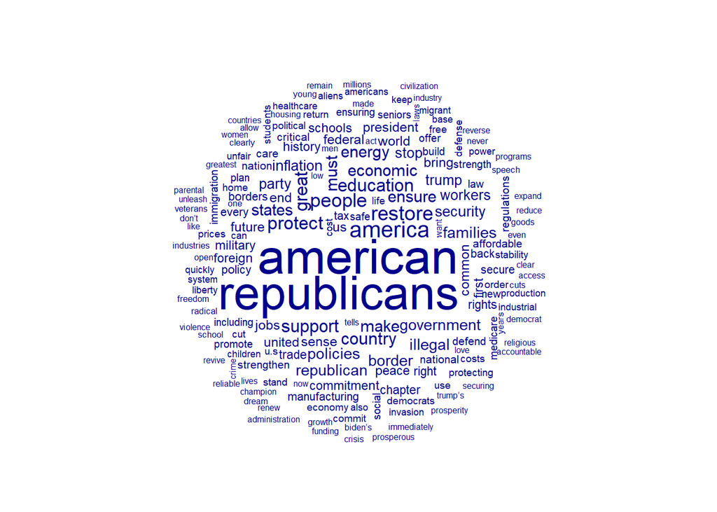

```r
textplot_wordcloud(trump_dfmat, max_words = 180)
```

```r
trump_dfmat <- dfm_remove(trump_dfmat, pattern = c("every", "years", "even", "us", "also", "Biden’s", "made", "trump’s", "can", "don’t", "chapter", "including", "one", "without", "u.s", "like", "millions", "trump", "must", "president"))
```

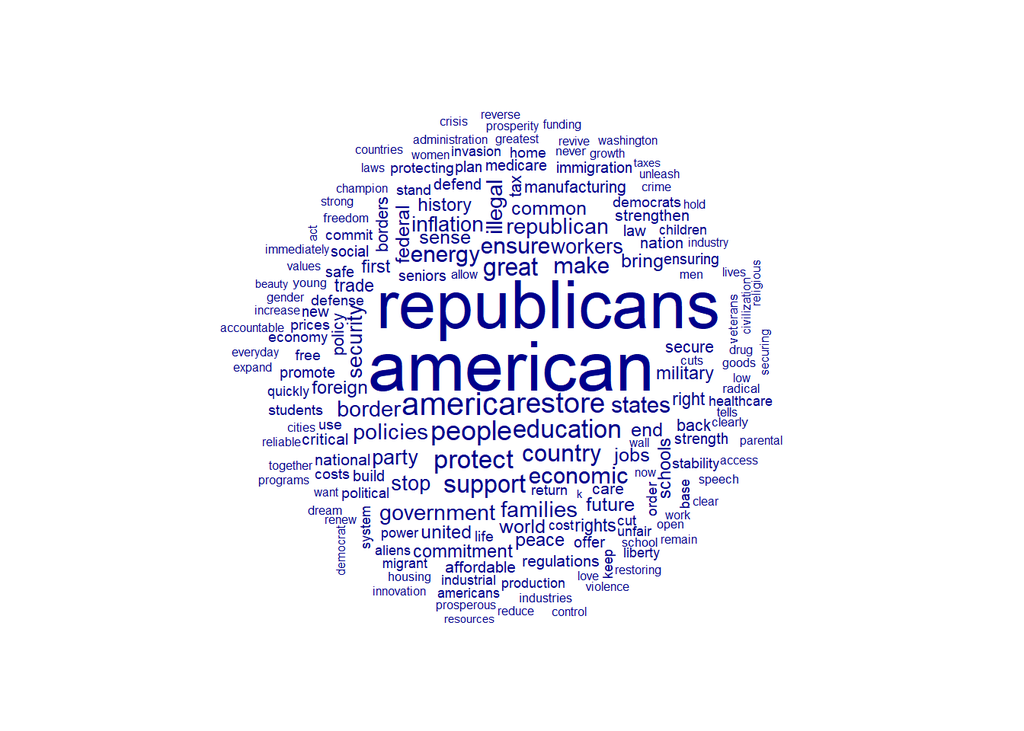

```r
textplot_wordcloud(trump_dfmat, max_words = 180)
```

The word Republicans is as frequent as american. Other frequent words are america, restore, great, people, education, protect and support which shows that restoring america, protecting it and making it a great country is his priorities. Education also seems to be his major focus. But let’s have a look at education in context to see what is Trump’s view regarding “education”.

```r
kw_trump <- trump_toks %>%
  kwic(pattern = "education")
print(head(kw_trump, 15))
```

```
## Keyword-in-context with 15 matches.
##   [text146, 4]                           driven cost housing | education |
##  [text222, 11]      dream affordable commit reducing housing | education |
##   [text228, 3]                             accessible higher | education |
##   [text229, 4]                            reduce cost higher | education |
##   [text290, 5]                restore parental rights commit | education |
##   [text291, 3]                               american values | education |
##   [text296, 7]        believe families empowered choose best | education |
##   [text297, 7]             choice every state america expand | education |
##   [text300, 3]                         republicans emphasize | education |
##   [text301, 8] meaningful work experience expose politicized | education |
##   [text307, 5]           republicans restore parental rights | education |
##   [text313, 6]         promote love country authentic civics | education |
##   [text314, 8]      commission promote fair patriotic civics | education |
##   [text315, 3]                            nationalize civics | education |
##   [text319, 2]                                        return | education |
##
##  healthcare american families
##
##
##  republicans support creation additional drastically
##  system empowers students supports families
##  system must prepare students successful
##  children support universal
##  savings accounts support homeschooling
##  prepare students great jobs careers
##  models fund proven career
##  enforce civil rights laws stop
##
##  veto efforts
##  support schools teach america’s founding
##  states
```

Yes, it seems that Trump plans to make education more accessible and reduce costs of higher education.

#### Keyness Plot

To create a keyness plot, I will combine the two datasets. I will use Harris’s “A New Way Forward” document.

```r
harris_trump <- rbind(harris_dfmat_2, trump_dfmat)
```

textstat_keyness function allows to look at keywords as separated by candidate. I will indicate the target category as documents classified as Harris. This means the documents associated with Trump are reference.

```r
tstat_key_policy <- textstat_keyness(harris_trump, target = docvars(harris_trump, "candidate") == "harris")

head(tstat_key_policy)
```

```
##            feature      chi2            p n_target n_reference
## 1        americans 150.55290 0.000000e+00      196           6
## 2              tax 118.74702 0.000000e+00      171          10
## 3         governor  58.60119 1.931788e-14       70           0
## 4       businesses  56.65393 5.195844e-14       71           1
## 5 small_businesses  55.22045 1.076916e-13       66           0
## 6            costs  48.56865 3.189227e-12       79           7
```

```r
tail(tstat_key_policy)
```

```
##          feature      chi2            p n_target n_reference
## 1348   education -25.41679 4.618811e-07        0          21
## 1349     protect -26.63095 2.462665e-07        0          22
## 1350      people -27.84547 1.314013e-07        0          23
## 1351     restore -30.27556 3.748199e-08        0          25
## 1352 republicans -86.55746 0.000000e+00        0          71
## 1353    american -90.25417 0.000000e+00        0          74
```

Let’s draw a keyness plot:

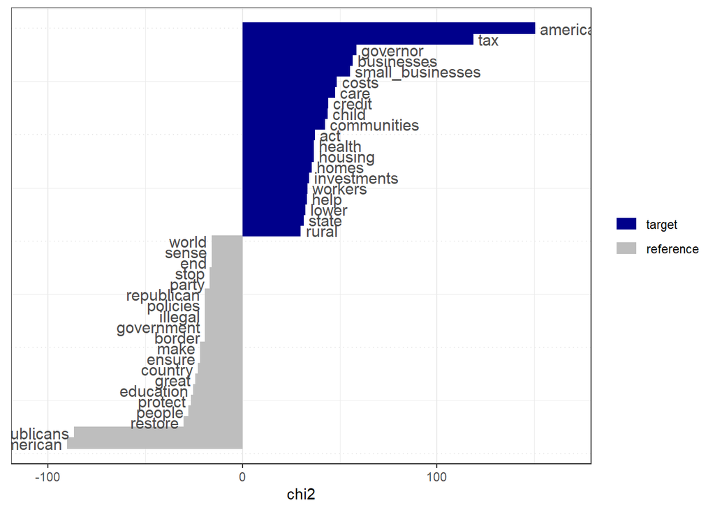

```r
textplot_keyness(tstat_key_policy)
```

Harris has used the word “small” apart from “small businesses”. Let’s have a look at the context where small has been used:

```r
kw_small <- harris_toks %>%
  kwic(pattern = "small")
print(head(kw_small, 15))
```

```
## Keyword-in-context with 15 matches.
##   [text60, 16]                  one-third federal contract dollars go | small |
##    [text63, 5]                            trump long history stiffing | small |
##   [text99, 18] many federal housing administration-backed loans—loans | small |
##   [text262, 5]                       industries future—in rural areas | small |
##   [text269, 7]                    president harris governor walz know | small |
##   [text270, 4]                               shops high-tech startups | small |
##   [text507, 5]             assistance administration already provided | small |
##   [text514, 2]                                              suppliers | small |
##   [text839, 3]                                      middlemen squeeze | small |
##  [text1314, 6]               administration fha backed loans—or loans | small |
##  [text1352, 4]                               shops high-tech startups | small |
##  [text1414, 7]                       red tape including making easier | small |
##  [text1419, 7]                    president harris governor walz lift | small |
##  [text1449, 3]                                          revival young | small |
##  [text1463, 6]                          tax start make profit example | small |
##
##  businesses—including commitment go small_businesses started
##  construction companies hired refused pay—showing
##  payment many first-time latino homeowners
##  towns suburbs big cities
##  businesses—neighborhood
##  manufacturers more—are engines economy
##
##  farms growers processors create federal
##  pharmacies profits
##  payment top
##  manufacturers
##
##
##  innovative firms
##  governor walz’s plans remove barriers
```

As we saw earlier, the most frequent words in Harris’s agenda are tax, small businesses, costs, care, child, communities, health, housing and workers. It is clear that she has plans in the issues of tax, businesses in particular small businesses, health care, issues related to other communities such as Latino and Black communities, housing and addressing issues related to working families. In Trump’s agenda, however, the most frequent words are restore, people, protect, education, great, country, border and illegal. It is clear that Trump has general plans and there aren’t specific issues that he seeks to address except education and illegal immigration or border control.